# Prevalence ~30%: the current constructions across the p30 cells

Naive, MR (IJ) and MR (field) for both blocks, and the joint pair, under a ~30% harm subgroup (TASK_prevalence30_2026-09-06)

Author

Larry León

Published

September 6, 2026

The four `p30` cells plant the harm subgroup in `{er ≤ q₀.₆₀(er)} ∩ {meno = 0}` (prevalence 0.3065 on the super-population; M1’s `{er ≤ 8} ∩ {meno = 0}` is 12.4%). Every complement result before this came from designs where near-tied candidates have near-identical complements, so the complement’s selection variability was negligible — a regime, not a property of any method. The constructions here are the current set only: naive and oracle as references, MR (IJ, two-term), MR (field), and the joint pair; the displays use the Gaussian bookkeeping reference (harm block: lower bound, $\Phi(z_{0.95} r - b)$; complement block: upper bound, $\Phi(z_{0.95} r + b)$).

# 1 Knobs

```r
library(forestsearch)
library(ggplot2)
library(kableExtra)
`%||%` <- function(a, b) if (is.null(a) || length(a) == 0 || all(is.na(a))) b else a
globs <- strsplit(Sys.getenv("FS_SUMP_GLOBS",
                  "results/fs_*_z1q60_p30_combined_1_2000.rds"),
                  ";", fixed = TRUE)[[1]]
estimators <- c("naive", "mr", "fld")
curves     <- c(1, 1.25, 1.5, 2)
cell_label <- function(meta, f) {
  hr <- meta$target_hr_harm
  base <- if (hr < 1) sprintf("protective %.2f", hr)
  else if (hr == 1) "null 1.0" else sprintf("harm %.4g", hr)
  base <- paste0(base, sprintf(", prev %.0f%%", 100 * (meta$harm_prevalence_super %||% NA)))
  kn <- as.integer(sub("^.*_knoise(\\d+)_.*$", "\\1", basename(f)))
  nn <- if (meta$n_sample == 500) if (kn > 0 || hr < 1) "" else ", n=500" else sprintf(", n=%d", meta$n_sample)
  paste0(base, nn, if (kn > 0) sprintf(", %d noise", kn) else "")
}
files <- sort(unlist(lapply(globs, Sys.glob)))
stopifnot(length(files) > 0)
bundles <- lapply(files, readRDS)
labels  <- mapply(cell_label, lapply(bundles, `[[`, "meta"), files)
```

# 2 Complement block (one-sided = upper bound)

```r
tabC <- do.call(rbind, lapply(seq_along(bundles), function(i) {
  s <- fs_sim_bias_coverage(bundles[[i]]$results, block = "Hc", estimators = estimators, side = "upper")
  s$cell <- labels[i]; s
}))
tabC$estimator <- factor(tabC$estimator, levels = c("naive", "mr", "fld"),
                         labels = c("naive", "IJ two-term", "field"))
kbl(tabC[, c("cell", "estimator", "n", "b", "r", "cov1", "cov1_wilson_lo", "cov1_wilson_hi",
             "cov2", "cov2_wilson_lo", "cov2_wilson_hi", "cov1_ref", "cov2_ref")],
    digits = 3, booktabs = TRUE, row.names = FALSE,
    caption = "Complement block; cov1 = one-sided 95% UPPER-bound coverage of beta(Hhat^c).") |>
  kable_styling(font_size = 12)
```

Complement block; cov1 = one-sided 95% UPPER-bound coverage of beta(Hhat^c).

| cell | estimator | n | b | r | cov1 | cov1_wilson_lo | cov1_wilson_hi | cov2 | cov2_wilson_lo | cov2_wilson_hi | cov1_ref | cov2_ref |
| --- | --- | --- | --- | --- | --- | --- | --- | --- | --- | --- | --- | --- |
| null 1.0, prev 31%, n=1000 | naive | 1909 | -0.742 | 1.003 | 0.832 | 0.814 | 0.848 | 0.904 | 0.890 | 0.916 | 0.818 | 0.886 |
| null 1.0, prev 31%, n=1000 | IJ two-term | 1909 | -0.216 | 1.856 | 0.997 | 0.993 | 0.999 | 1.000 | 0.998 | 1.000 | 0.998 | 1.000 |
| null 1.0, prev 31%, n=1000 | field | 1909 | -0.113 | 0.965 | 0.936 | 0.924 | 0.946 | 0.944 | 0.933 | 0.954 | 0.930 | 0.940 |
| null 1.0, prev 31%, n=500 | naive | 1841 | -0.865 | 1.043 | 0.798 | 0.779 | 0.816 | 0.889 | 0.874 | 0.903 | 0.803 | 0.879 |
| null 1.0, prev 31%, n=500 | IJ two-term | 1841 | -0.305 | 1.895 | 0.997 | 0.994 | 0.999 | 0.999 | 0.997 | 1.000 | 0.998 | 1.000 |
| null 1.0, prev 31%, n=500 | field | 1841 | -0.201 | 0.990 | 0.923 | 0.910 | 0.934 | 0.946 | 0.934 | 0.955 | 0.923 | 0.943 |
| harm 1.5, prev 31%, n=500 | naive | 1999 | -0.737 | 0.972 | 0.808 | 0.790 | 0.825 | 0.879 | 0.864 | 0.893 | 0.806 | 0.874 |
| harm 1.5, prev 31%, n=500 | IJ two-term | 1999 | -0.262 | 1.807 | 0.997 | 0.993 | 0.999 | 0.999 | 0.997 | 1.000 | 0.997 | 0.999 |
| harm 1.5, prev 31%, n=500 | field | 1999 | -0.183 | 0.939 | 0.921 | 0.909 | 0.932 | 0.942 | 0.931 | 0.952 | 0.913 | 0.930 |
| harm 1.75, prev 31%, n=500 | naive | 1999 | -0.645 | 0.950 | 0.826 | 0.809 | 0.842 | 0.893 | 0.879 | 0.906 | 0.820 | 0.882 |
| harm 1.75, prev 31%, n=500 | IJ two-term | 1999 | -0.212 | 1.767 | 0.997 | 0.993 | 0.999 | 0.999 | 0.997 | 1.000 | 0.996 | 0.999 |
| harm 1.75, prev 31%, n=500 | field | 1999 | -0.148 | 0.917 | 0.923 | 0.910 | 0.934 | 0.940 | 0.929 | 0.950 | 0.913 | 0.925 |

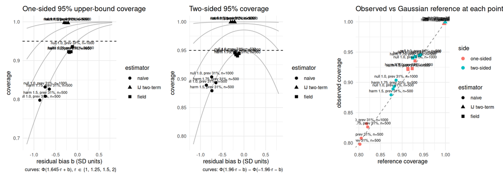

```r
fs_plot_bias_coverage(tabC, curves = curves, side = "upper")
```

# 3 Harm block (one-sided = lower bound)

```r
tabH <- do.call(rbind, lapply(seq_along(bundles), function(i) {
  s <- fs_sim_bias_coverage(bundles[[i]]$results, block = "H", estimators = estimators, side = "lower")
  s$cell <- labels[i]; s
}))
tabH$estimator <- factor(tabH$estimator, levels = c("naive", "mr", "fld"),
                         labels = c("naive", "IJ two-term", "field"))
kbl(tabH[, c("cell", "estimator", "n", "b", "r", "cov1", "cov1_wilson_lo", "cov1_wilson_hi",
             "cov2", "cov2_wilson_lo", "cov2_wilson_hi", "cov1_ref", "cov2_ref")],
    digits = 3, booktabs = TRUE, row.names = FALSE,
    caption = "Harm block; cov1 = one-sided 95% LOWER-bound coverage of beta(Hhat).") |>
  kable_styling(font_size = 12)
```

Harm block; cov1 = one-sided 95% LOWER-bound coverage of beta(Hhat).

| cell | estimator | n | b | r | cov1 | cov1_wilson_lo | cov1_wilson_hi | cov2 | cov2_wilson_lo | cov2_wilson_hi | cov1_ref | cov2_ref |
| --- | --- | --- | --- | --- | --- | --- | --- | --- | --- | --- | --- | --- |
| null 1.0, prev 31%, n=1000 | naive | 1909 | 3.613 | 1.635 | 0.177 | 0.160 | 0.194 | 0.365 | 0.343 | 0.386 | 0.178 | 0.342 |
| null 1.0, prev 31%, n=1000 | IJ two-term | 1909 | 0.751 | 1.575 | 0.968 | 0.959 | 0.975 | 0.988 | 0.983 | 0.992 | 0.967 | 0.990 |
| null 1.0, prev 31%, n=1000 | field | 1909 | 0.322 | 1.157 | 0.944 | 0.933 | 0.954 | 0.966 | 0.957 | 0.974 | 0.943 | 0.969 |
| null 1.0, prev 31%, n=500 | naive | 1841 | 4.067 | 1.780 | 0.131 | 0.116 | 0.147 | 0.300 | 0.279 | 0.321 | 0.127 | 0.281 |
| null 1.0, prev 31%, n=500 | IJ two-term | 1841 | 0.806 | 1.749 | 0.978 | 0.970 | 0.984 | 0.991 | 0.985 | 0.994 | 0.981 | 0.996 |
| null 1.0, prev 31%, n=500 | field | 1841 | 0.319 | 1.334 | 0.972 | 0.963 | 0.978 | 0.986 | 0.979 | 0.990 | 0.970 | 0.987 |
| harm 1.5, prev 31%, n=500 | naive | 1999 | 2.839 | 1.495 | 0.385 | 0.364 | 0.406 | 0.544 | 0.522 | 0.566 | 0.352 | 0.536 |
| harm 1.5, prev 31%, n=500 | IJ two-term | 1999 | 0.383 | 1.502 | 0.977 | 0.970 | 0.983 | 0.990 | 0.985 | 0.994 | 0.982 | 0.994 |
| harm 1.5, prev 31%, n=500 | field | 1999 | 0.068 | 1.160 | 0.967 | 0.959 | 0.974 | 0.959 | 0.949 | 0.967 | 0.967 | 0.977 |
| harm 1.75, prev 31%, n=500 | naive | 1999 | 2.470 | 1.416 | 0.469 | 0.447 | 0.491 | 0.623 | 0.602 | 0.644 | 0.444 | 0.620 |
| harm 1.75, prev 31%, n=500 | IJ two-term | 1999 | 0.265 | 1.430 | 0.981 | 0.975 | 0.987 | 0.988 | 0.982 | 0.992 | 0.982 | 0.993 |
| harm 1.75, prev 31%, n=500 | field | 1999 | 0.009 | 1.111 | 0.967 | 0.959 | 0.974 | 0.950 | 0.940 | 0.959 | 0.965 | 0.971 |

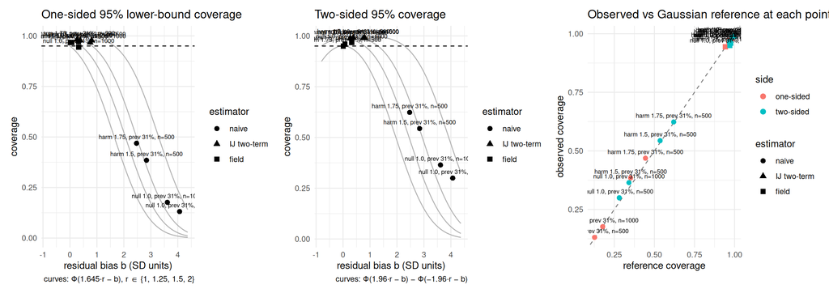

```r
fs_plot_bias_coverage(tabH, curves = curves, side = "lower")
```

# 4 The simultaneous pair

```r
wil <- function(x, n, z = qnorm(.975)) { c <- (x + z^2/(2*n))/(1+z^2/n); h <- z*sqrt(x*(1-x)/n + z^2/(4*n^2))/(1+z^2/n); c(c - h, c + h) }
tabJ <- do.call(rbind, lapply(seq_along(bundles), function(i) {
  r <- bundles[[i]]$results; d <- r[r$detected %in% 1L, ]
  d <- d[is.finite(d$betaHhat_H) & is.finite(d$betaHhat_Hc) & is.finite(d$fld_joint_gamma), ]
  pairs <- list(`separate 95%` = list(lo = d$fld_H_lo1s, up = d$fld_Hc_up1s),
                `Bonferroni`   = list(lo = d$fld_joint_bonf_loH, up = d$fld_joint_bonf_upHc),
                `calibrated`   = list(lo = d$fld_joint_loH, up = d$fld_joint_upHc))
  do.call(rbind, lapply(names(pairs), function(nm) { p <- pairs[[nm]]
    cH <- d$betaHhat_H >= p$lo; cC <- d$betaHhat_Hc <= p$up; jc <- mean(cH & cC); w <- wil(jc, nrow(d))
    data.frame(cell = labels[i], pair = nm, n = nrow(d), joint_cov = jc, wilson_lo = w[1], wilson_hi = w[2],
               cov_H = mean(cH), cov_Hc = mean(cC),
               margin_H = mean(log(d$mr_H_est) - log(p$lo)), margin_Hc = mean(log(p$up) - log(d$mr_Hc_est)),
               mean_gamma = mean(d$fld_joint_gamma), mean_corr = mean(d$fld_joint_corr), stringsAsFactors = FALSE) }))
}))
kbl(tabJ, digits = 3, booktabs = TRUE, row.names = FALSE,
    caption = "Joint coverage of (beta(Hhat) >= lower_H, beta(Hhat^c) <= upper_Hc) with Wilson intervals; margins on the log scale from the two-term de-biased estimates.") |>
  kable_styling(font_size = 12)
```

Joint coverage of (beta(Hhat) >= lower_H, beta(Hhat^c) <= upper_Hc) with Wilson intervals; margins on the log scale from the two-term de-biased estimates.

| cell | pair | n | joint_cov | wilson_lo | wilson_hi | cov_H | cov_Hc | margin_H | margin_Hc | mean_gamma | mean_corr |
| --- | --- | --- | --- | --- | --- | --- | --- | --- | --- | --- | --- |
| null 1.0, prev 31%, n=1000 | separate 95% | 1909 | 0.882 | 0.867 | 0.896 | 0.944 | 0.936 | 0.529 | 0.162 | 0.025 | 0.069 |
| null 1.0, prev 31%, n=1000 | Bonferroni | 1909 | 0.939 | 0.927 | 0.949 | 0.976 | 0.963 | 0.634 | 0.191 | 0.025 | 0.069 |
| null 1.0, prev 31%, n=1000 | calibrated | 1909 | 0.939 | 0.927 | 0.949 | 0.976 | 0.963 | 0.634 | 0.191 | 0.025 | 0.069 |
| null 1.0, prev 31%, n=500 | separate 95% | 1841 | 0.896 | 0.881 | 0.909 | 0.972 | 0.923 | 0.718 | 0.231 | 0.025 | 0.066 |
| null 1.0, prev 31%, n=500 | Bonferroni | 1841 | 0.949 | 0.938 | 0.958 | 0.991 | 0.958 | 0.863 | 0.273 | 0.025 | 0.066 |
| null 1.0, prev 31%, n=500 | calibrated | 1841 | 0.949 | 0.938 | 0.958 | 0.991 | 0.958 | 0.863 | 0.273 | 0.025 | 0.066 |
| harm 1.5, prev 31%, n=500 | separate 95% | 1999 | 0.890 | 0.876 | 0.903 | 0.967 | 0.921 | 0.685 | 0.225 | 0.025 | 0.043 |
| harm 1.5, prev 31%, n=500 | Bonferroni | 1999 | 0.948 | 0.937 | 0.957 | 0.988 | 0.959 | 0.825 | 0.266 | 0.025 | 0.043 |
| harm 1.5, prev 31%, n=500 | calibrated | 1999 | 0.948 | 0.937 | 0.957 | 0.988 | 0.959 | 0.825 | 0.266 | 0.025 | 0.043 |
| harm 1.75, prev 31%, n=500 | separate 95% | 1999 | 0.893 | 0.879 | 0.906 | 0.967 | 0.923 | 0.671 | 0.223 | 0.025 | 0.029 |
| harm 1.75, prev 31%, n=500 | Bonferroni | 1999 | 0.946 | 0.936 | 0.956 | 0.986 | 0.959 | 0.810 | 0.264 | 0.025 | 0.029 |
| harm 1.75, prev 31%, n=500 | calibrated | 1999 | 0.946 | 0.935 | 0.955 | 0.986 | 0.959 | 0.809 | 0.263 | 0.025 | 0.029 |

# 5 Reading

Complement, one-sided upper coverage: naive 0.832/0.798/0.808/0.826 (r = 1.00/1.04/0.97/0.95); IJ two-term 0.997/0.997/0.997/0.997 (r = 1.86/1.89/1.81/1.77); field 0.936/0.923/0.921/0.923 (r = 0.96/0.99/0.94/0.92). Harm, one-sided lower coverage: naive 0.177/0.131/0.385/0.469; IJ two-term 0.968/0.978/0.977/0.981 (r = 1.58/1.75/1.50/1.43); field 0.944/0.972/0.967/0.967 (r = 1.16/1.33/1.16/1.11). Joint pair: calibrated coverage 0.939/0.949/0.948/0.946 (mean gamma 0.0251/0.0251/0.0251/0.0251, mean corr +0.069/+0.066/+0.043/+0.029) vs Bonferroni 0.939/0.949/0.948/0.946 vs separate 95% bounds 0.882/0.896/0.890/0.893.